# Modern Approaches to Data Analysis Quesiton 4

Please analyze these data and keep an R notebook, showing all the steps and including a narrative of your analysis. This narrative should include all steps, taken to determine the proper analysis, diagnostics, choice of inference, and interpretation. This will include coding the correct analysis, initial exploratory plots, diagnostic plots, and inferential methods, and data summaries (e.g. CIs, model predictions, etc.) Please submit your R notebook and a separate word or pdf file that contains the final plot and 1 paragraph explanation/interpretation of your findings (please collate all of your answers into a single word or pdf, but keep your R notebooks separate).

Here are many of the libraries you may need, but may not be comprehensive so don’t hesitate to add more that you need.

```r
require(qualityTools)
require(lme4)
```

```r
require(ggplot2)
require(dotwhisker)
require(bbmle)
require(emdbook)
require(AICcmodavg)
require(glmmTMB)
require(gridExtra)
library(blme)
library(tidyverse)
require(broom.mixed)
```

**Problem 4-Plasticity in Life Stage Transitions**

```
## 'data.frame':    2493 obs. of  14 variables:
##  $ Ind              : int  1 2 3 4 5 6 7 8 9 10 ...
##  $ Block            : int  5 5 5 5 5 5 5 2 2 1 ...
##  $ Tank             : int  7 4 4 7 10 4 4 5 4 1 ...
##  $ Tank.Unique      : int  55 52 52 55 58 52 52 17 16 1 ...
##  $ Hatch            : chr  "E" "L" "L" "E" ...
##  $ Pred             : chr  "NL" "C" "C" "NL" ...
##  $ Res              : chr  "Hi" "Hi" "Hi" "Hi" ...
##  $ Age.DPO          : int  35 35 35 35 36 36 36 39 39 39 ...
##  $ Age.FromEmergence: int  1 1 1 1 2 2 2 5 5 5 ...
##  $ SVL.initial      : num  18 17.7 18.1 16.8 18.7 17.5 17.3 19.6 16.5 17.5 ...
##  $ Tail.initial     : num  5.4 1.1 5 6.4 6.3 4.4 1.3 1.5 2 5.1 ...
##  $ SVL.final        : num  17 18 17.8 17.1 19.3 17.8 17.9 19.6 17.7 19.5 ...
##  $ Mass.final       : num  0.38 0.35 0.41 0.3 0.46 0.3 0.42 0.5 0.33 0.46 ...
##  $ Resorb.days      : int  3 3 3 3 3 4 2 2 2 3 ...
```

|  | Ind | Block | Tank | Tank.Unique | Hatch | Pred | Res | Age.DPO | Age.FromEmergence | SVL.initial | Tail.initial | SVL.final | Mass.final | Resorb.days |
| --- | --- | --- | --- | --- | --- | --- | --- | --- | --- | --- | --- | --- | --- | --- |
| 1 | 1 | 5 | 7 | 55 | E | NL | Hi | 35 | 1 | 18.0 | 5.4 | 17.0 | 0.38 | 3 |
| 2 | 2 | 5 | 4 | 52 | L | C | Hi | 35 | 1 | 17.7 | 1.1 | 18.0 | 0.35 | 3 |
| 3 | 3 | 5 | 4 | 52 | L | C | Hi | 35 | 1 | 18.1 | 5.0 | 17.8 | 0.41 | 3 |
| 4 | 4 | 5 | 7 | 55 | E | NL | Hi | 35 | 1 | 16.8 | 6.4 | 17.1 | 0.30 | 3 |
| 5 | 5 | 5 | 10 | 58 | L | L | Hi | 36 | 2 | 18.7 | 6.3 | 19.3 | 0.46 | 3 |
| 6 | 6 | 5 | 4 | 52 | L | C | Hi | 36 | 2 | 17.5 | 4.4 | 17.8 | 0.30 | 4 |

```r
library(viridis)
```

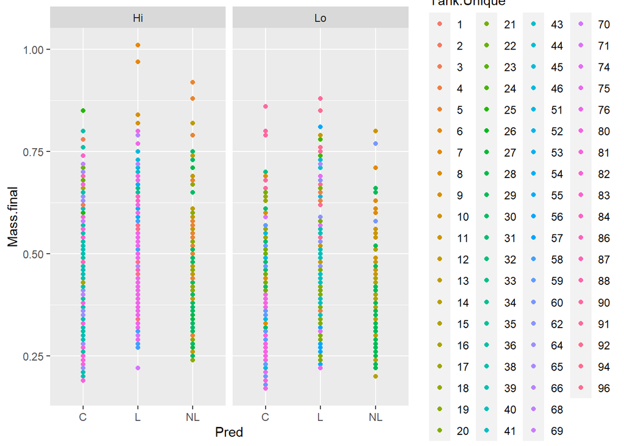

```r
ggplot(data = RxP, aes(x=Pred, y=Mass.final, colour= Tank.Unique, color = as.factor(Tank.Unique))) +
    geom_point() + facet_wrap(~Res)
```

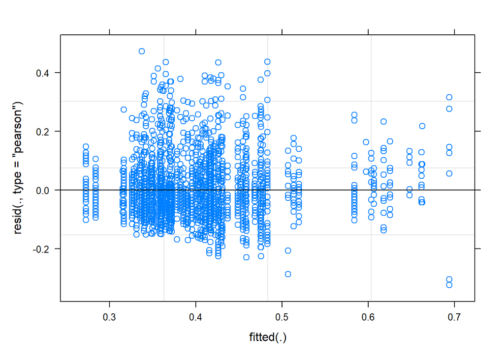

```r
m2 <- lmer(Mass.final ~ Pred + Res + (1 | Tank.Unique),data = RxP)
plot(m2)
```

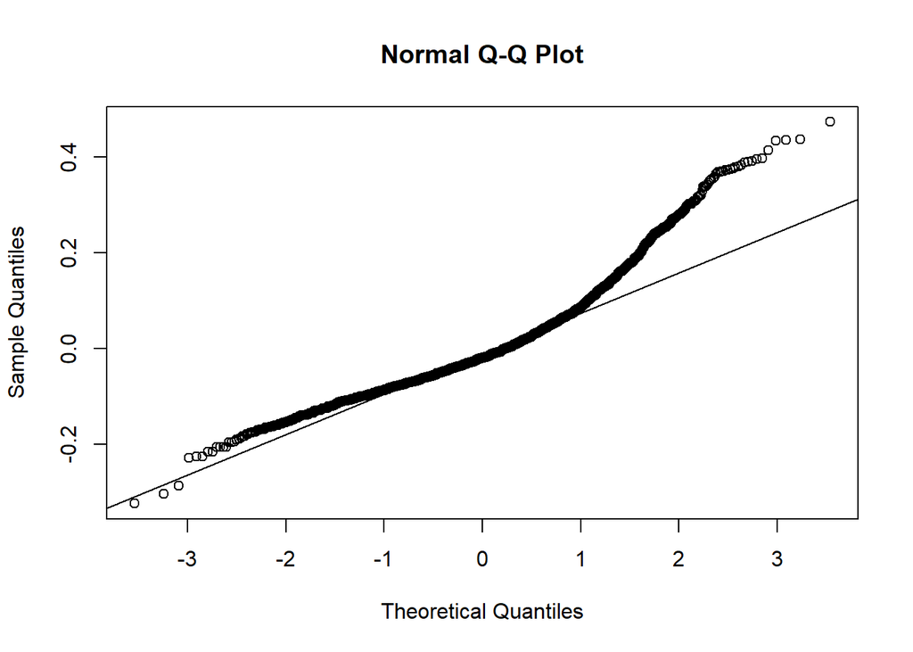

```r
qqnorm(resid(m2))
qqline(resid(m2))
```

```r
library(aods3)
gof(m2)
```

```
## D  = -3961.398, df = 2487, P(>D) = 1
## X2 = 26.3088, df = 2487, P(>X2) = 1
```

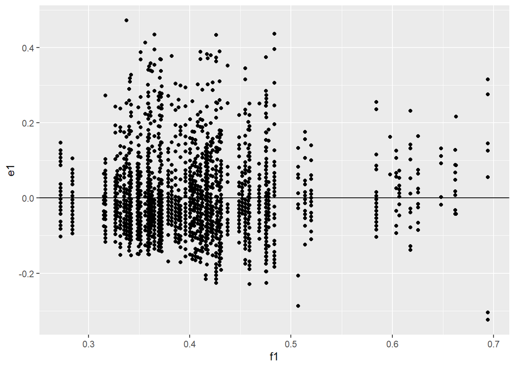

```r
e1=resid(m2)
f1=fitted(m2)
qplot(x=f1,y=e1)+geom_point()+geom_hline(yintercept=0)
```

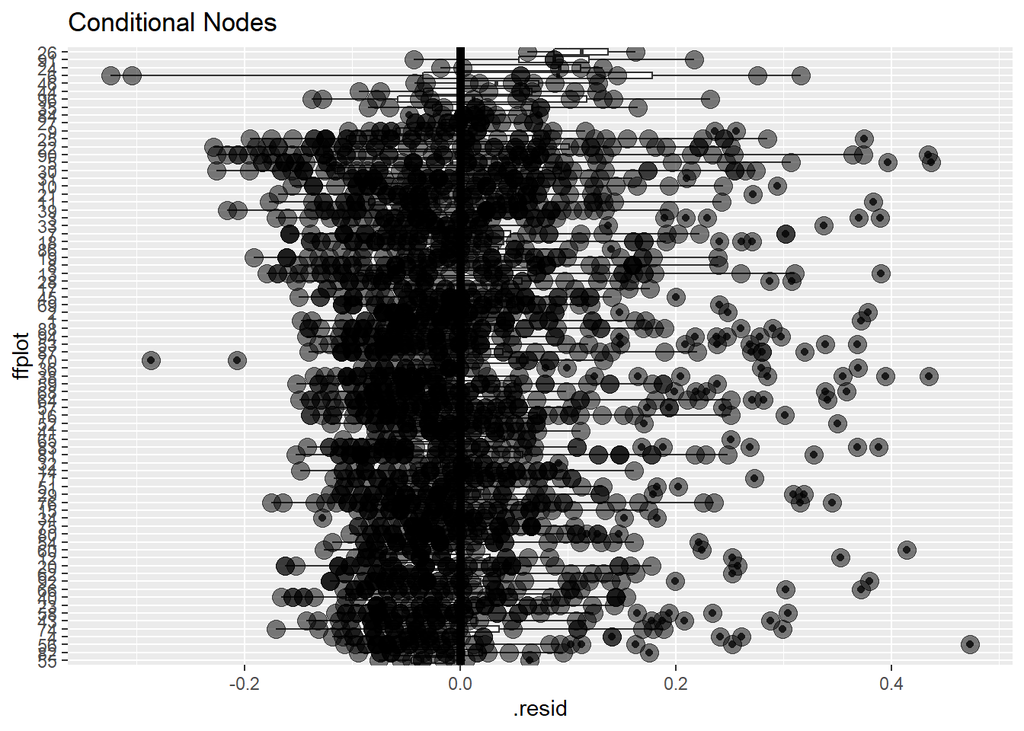

```r
library(broom.mixed)
ff <- augment(m2)
ff <- transform(ff,ffplot=reorder(Tank.Unique,X=.resid,FUN=mean,sort=sort))
ggplot(ff,aes(x=ffplot,y=.resid))+geom_boxplot()+geom_point(size=4,alpha=0.5)+geom_hline(yintercept=0,size=2)+
 coord_flip()+ggtitle("Conditional Nodes")
```

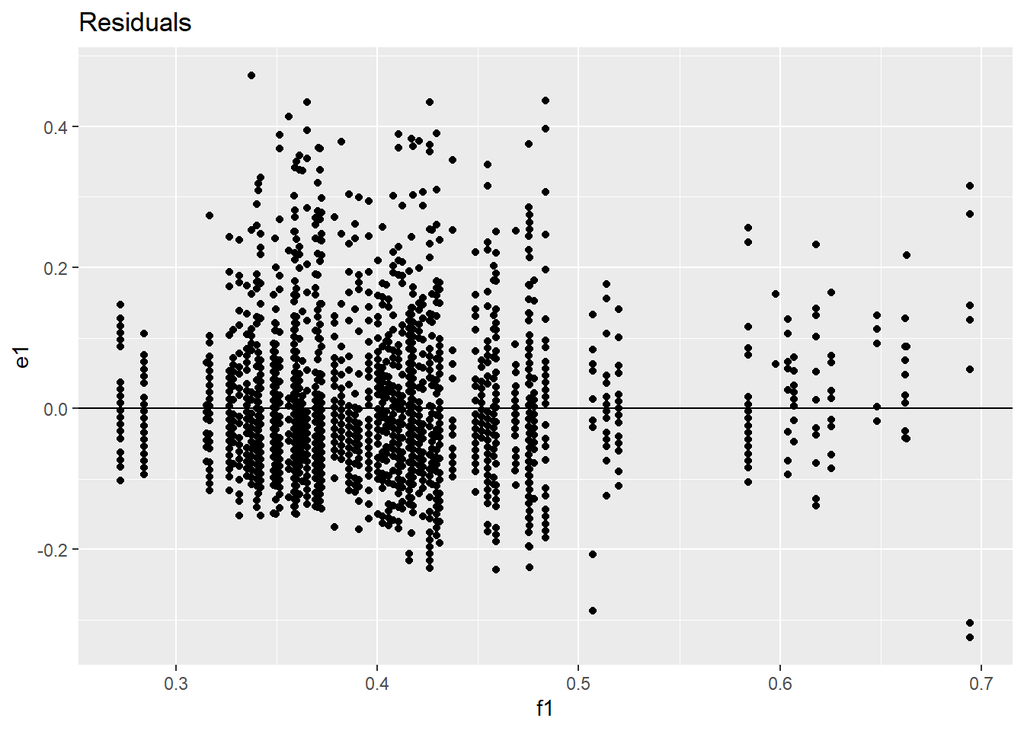

```r
qplot(x=f1,y=e1)+geom_point()+geom_hline(yintercept=0)+ggtitle("Residuals")
```

```r
summary(m2)
```

```
## Linear mixed model fit by REML ['lmerMod']
## Formula: Mass.final ~ Pred + Res + (1 | Tank.Unique)
##    Data: RxP
##
## REML criterion at convergence: -3961.4
##
## Scaled residuals:
##     Min      1Q  Median      3Q     Max
## -3.1103 -0.6532 -0.1950  0.4378  4.5324
##
## Random effects:
##  Groups      Name        Variance Std.Dev.
##  Tank.Unique (Intercept) 0.005714 0.07559
##  Residual                0.010868 0.10425
## Number of obs: 2493, groups:  Tank.Unique, 78
##
## Fixed effects:
##             Estimate Std. Error t value
## (Intercept)  0.38262    0.01632  23.451
## PredL        0.12970    0.01973   6.574
## PredNL       0.03621    0.02494   1.452
## ResLo       -0.03284    0.01783  -1.842
##
## Correlation of Fixed Effects:
##        (Intr) PredL  PredNL
## PredL  -0.588
## PredNL -0.459  0.380
## ResLo  -0.545  0.012 -0.002
```

```r
m3 <- lmer(Mass.final ~ Pred + Res +  (1 | Tank.Unique), data = RxP, REML = FALSE)
m3a <- update(m3, .~. - Pred)
m3b <- update(m3, .~. - Res)

anova(m3,m3a)
```

|  | npar | AIC | BIC | logLik | deviance | Chisq | Df | Pr(>Chisq) |
| --- | --- | --- | --- | --- | --- | --- | --- | --- |
| m3a | 4 | -3941.52 | -3918.235 | 1974.76 | -3949.52 | NA | NA | NA |
| m3 | 6 | -3975.06 | -3940.133 | 1993.53 | -3987.06 | 37.53979 | 2 | 7.052432e-09 |

```r
anova(m3,m3b)
```

|  | npar | AIC | BIC | logLik | deviance | Chisq | Df | Pr(>Chisq) |
| --- | --- | --- | --- | --- | --- | --- | --- | --- |
| m3b | 5 | -3973.538 | -3944.431 | 1991.769 | -3983.538 | NA | NA | NA |
| m3 | 6 | -3975.060 | -3940.133 | 1993.530 | -3987.060 | 3.522554 | 1 | 0.06053907 |

```r
m2 <- lmer(Mass.final ~ Pred + Res + (1 | Tank.Unique),data = RxP)

WaldCI=confint(m2,method="Wald")

fixef(m2)
```

```
## (Intercept)       PredL      PredNL       ResLo
##  0.38262051  0.12970295  0.03621036 -0.03283893
```

```r
newdat=data.frame(type=rep("Wald",4),parameter=c("Int","PredL","PredNL","ResLo"),estimate=as.vector(fixef(m2)),lower=as.vector(WaldCI[3:6,1]),upper=as.vector(WaldCI[3:6,2]))
```

```r
library(lattice)
```

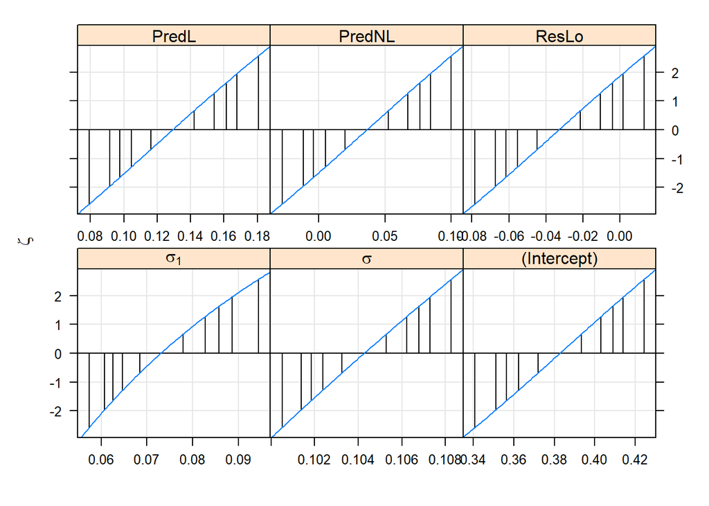

```r
p=profile(m2)
xyplot(p)
```

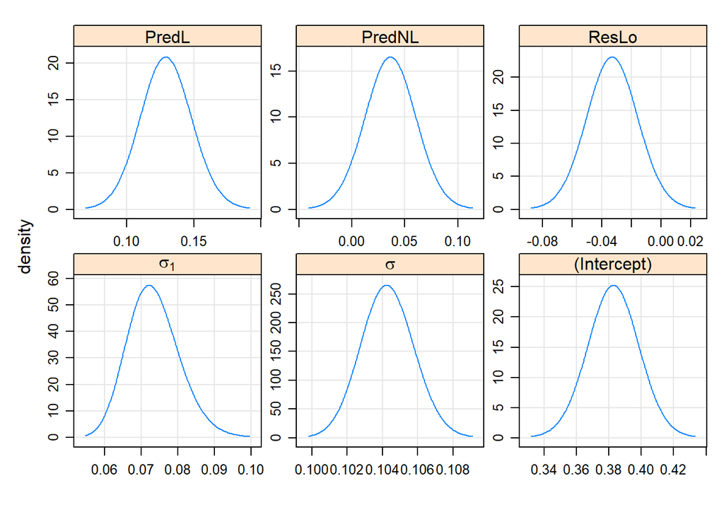

```r
densityplot(p)
```

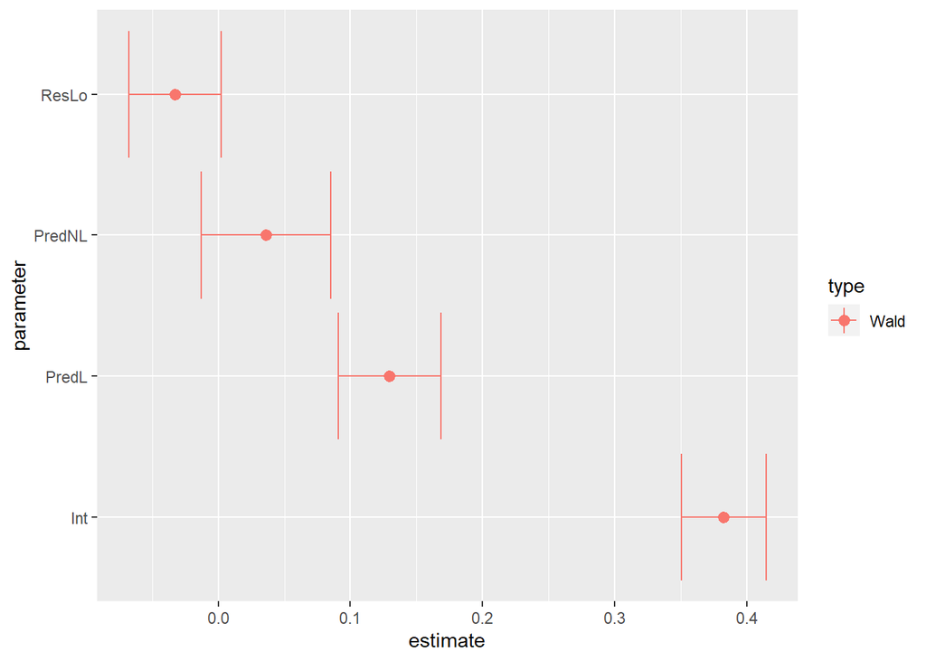

```r
ggplot(data=newdat,aes(x=parameter,y=estimate,ymin=lower,ymax=upper,group=type,color=type))+geom_point()+geom_errorbar(aes(ymin=lower,ymax=upper))+geom_pointrange(position=position_dodge(width=0.2))+coord_flip()
```

```r
library(broom.mixed)
library(car)
```

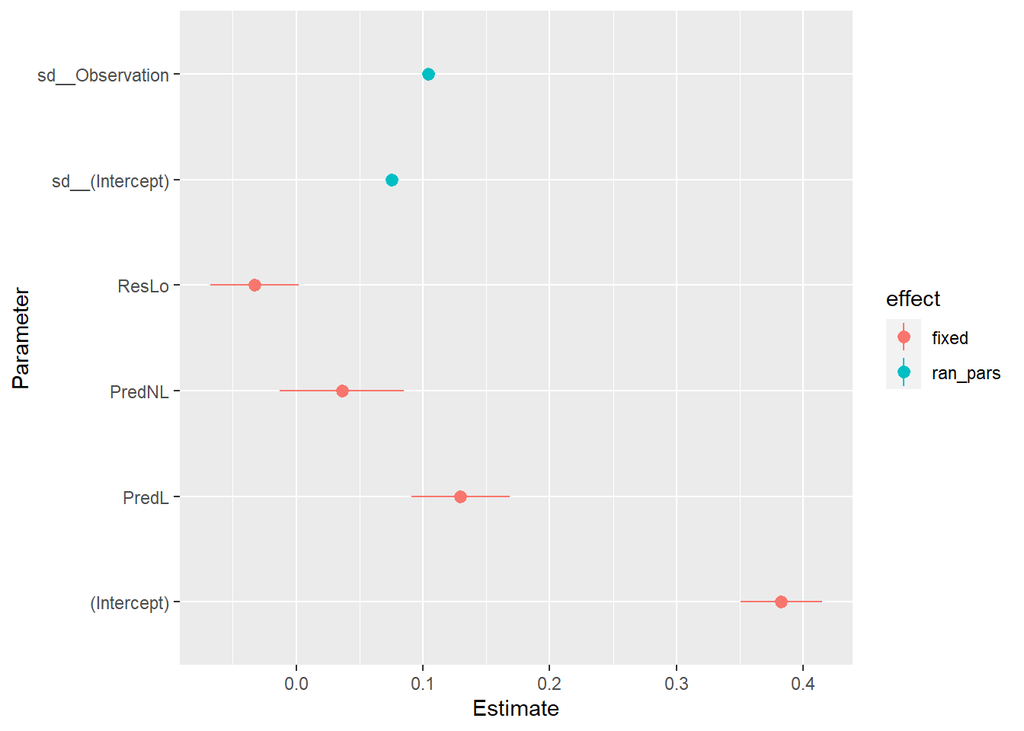

```r
c3 <- tidy(m2,conf.int = TRUE)
cmod_Results <- cbind(term=c3$term,(c3[,c(2,6:7)]),model="normal")

ggplot(c3,aes(x=term,y=estimate,ymin=conf.low,ymax=conf.high,colour=effect))+
  geom_pointrange(position=position_dodge(width=0.1))+coord_flip()+xlab("Parameter")+ylab("Estimate")
```

```r
m2
```

```
## Linear mixed model fit by REML ['lmerMod']
## Formula: Mass.final ~ Pred + Res + (1 | Tank.Unique)
##    Data: RxP
## REML criterion at convergence: -3961.398
## Random effects:
##  Groups      Name        Std.Dev.
##  Tank.Unique (Intercept) 0.07559
##  Residual                0.10425
## Number of obs: 2493, groups:  Tank.Unique, 78
## Fixed Effects:
## (Intercept)        PredL       PredNL        ResLo
##     0.38262      0.12970      0.03621     -0.03284
```

```r
Anova(m2,test="Chisq",type="2")
```

|  | Chisq | Df | Pr(>Chisq) |
| --- | --- | --- | --- |
| Pred | 44.499297 | 2 | 2.173204e-10 |
| Res | 3.393362 | 1 | 6.545936e-02 |

```r
#predmeans<-emmeans(m1,~Pred|Res)

#ggplot(data=newdat,aes(x=Mass.final,y=predmeans))+xlab("Mass.final")+ylab("Shannon Index")+geom_line(data=newdat,aes(x=Mass.final,y=predmeans))+geom_ribbon(data=newdat,aes(ymin=LL,ymax=UL),alpha=.2))+ geom_point(data=RxP,aes(x=Pred,y=Mass.final,colour=Res))

#pred.data=data.frame(beetle,predict(mod1, beetle, type = "link", se.fit=TRUE))
#pred.data=within(pred.data, {
  #predvals <- plogis(fit)
  #LL <- plogis(fit - 1.96 * se.fit)
  #UL <- plogis(fit + 1.96 * se.fit)})
#ggplot(data=pred.data,aes(x=Dose,y=predvals))+
  #xlab("Dose")+
  #ylab("Proportion of Beetles Surviving")+geom_line()+
  #geom_ribbon(aes(ymin=LL,ymax= UL),alpha=.2)+#scale_y_continuous(limits = c(0, 1))+
  #geom_point(data=beetle,aes(x = Dose,y = 1-Mortality_rate))


#For this question, a linear mixed model was used. A mixed model was applied because fixed and random effects are both present (fixed=explanatory variables, random=correlation w/in tank). The groups have been randomly selected from a population of groups. Observations from within the same tanks are most likely correlated, but tadpoles between sites are not. There are two covariates, predation and resource level. The random effect factor is the individual tanks. Based on the qqplot the data distribution is skewed to the right. There are two random effects, the unique tanks and the leftover residual variance. The random effects help to explain how much variation there is in the relationship between the mass of the tadpoles and predators/resources due to the fact that observations were from different tanks. Linearity in the xyplot supports the use of Wald's confidence intervals and the results of the density plot show that the data is Gaussian. The data is very underdispersed (based on gof results). Best model type to use is Gaussian based on the density plot and there are no counts or survival data. The results of the anova (chisq) show that:

#1) Leftover residual error has a higher standard deviation (variance) than the individual tanks.

#2) Predation has a significant effect on the final mass of the tadpoles.

#3) Resource availability had no significant effect on the final mass of the tadpoles.
```

**Question 2**

The data set for this question is called plantData.